# Investigate a Dataset: What factors contribute to whether a person is a no-show to a medical appointment?

- Introduction
- Data Wrangling
- Exploratory Data Analysis
- Conclusions

## Introduction

In this report, we will look at a dataset containing a list of Brazilian medical patients; of specific interest is whether or not they were a no-show to their medical appointments. The data contains demographic information and health information about each patient, as well as information about the scheduling of the appointment. The goal of this project, then, is to look at several of these variables and to try to make some conclusions about what contributes to the likelihood that a person does now show up to their appointment.

Here, we will look at three questions:

1) What is the relationship between gender and likelihood of a no-show?  
2) What is the relationship between age and likelihood of a no-show?  
3) How does the likelihood of a no-show vary with how far in advance an appointment is made? Is this affected by a patient receiving a text reminder?

For each question, we have the same dependent variable, which is the likelihood of a no-show. We aim to see what effect the independent variables of gender, age, appointment scheduling, and text reminders have on whether or not a person shows up.

```python
import pandas as pd
import numpy as np
import matplotlib.pyplot as plt
%matplotlib inline
```

## Data Wrangling

### General Properties

The first step is to load the data and look over the broader information about the dataframe. We do this by looking at the first few rows of the set and also calling df.info()

```python
# Load data and look at first few rows
df_appt = pd.read_csv('noshowappointments-kagglev2-may-2016.csv')
df_appt.head()
```

|  | PatientId | AppointmentID | Gender | ScheduledDay | AppointmentDay | Age | Neighbourhood | Scholarship | Hipertension | Diabetes | Alcoholism | Handcap | SMS_received | No-show |
| --- | --- | --- | --- | --- | --- | --- | --- | --- | --- | --- | --- | --- | --- | --- |
| 0 | 2.987250e+13 | 5642903 | F | 2016-04-29T18:38:08Z | 2016-04-29T00:00:00Z | 62 | JARDIM DA PENHA | 0 | 1 | 0 | 0 | 0 | 0 | No |
| 1 | 5.589978e+14 | 5642503 | M | 2016-04-29T16:08:27Z | 2016-04-29T00:00:00Z | 56 | JARDIM DA PENHA | 0 | 0 | 0 | 0 | 0 | 0 | No |
| 2 | 4.262962e+12 | 5642549 | F | 2016-04-29T16:19:04Z | 2016-04-29T00:00:00Z | 62 | MATA DA PRAIA | 0 | 0 | 0 | 0 | 0 | 0 | No |
| 3 | 8.679512e+11 | 5642828 | F | 2016-04-29T17:29:31Z | 2016-04-29T00:00:00Z | 8 | PONTAL DE CAMBURI | 0 | 0 | 0 | 0 | 0 | 0 | No |
| 4 | 8.841186e+12 | 5642494 | F | 2016-04-29T16:07:23Z | 2016-04-29T00:00:00Z | 56 | JARDIM DA PENHA | 0 | 1 | 1 | 0 | 0 | 0 | No |

```python
#Look at the datatype for each column, as well as for null values
df_appt.info()
```

```
<class 'pandas.core.frame.DataFrame'>
RangeIndex: 110527 entries, 0 to 110526
Data columns (total 14 columns):
PatientId         110527 non-null float64
AppointmentID     110527 non-null int64
Gender            110527 non-null object
ScheduledDay      110527 non-null object
AppointmentDay    110527 non-null object
Age               110527 non-null int64
Neighbourhood     110527 non-null object
Scholarship       110527 non-null int64
Hipertension      110527 non-null int64
Diabetes          110527 non-null int64
Alcoholism        110527 non-null int64
Handcap           110527 non-null int64
SMS_received      110527 non-null int64
No-show           110527 non-null object
dtypes: float64(1), int64(8), object(5)
memory usage: 11.8+ MB
```

info() lets us see the data types in the dataframe, so we know what we are working with and what we may need to change. We can also see that there are no null values in any of the columns in this dataframe. Therefore, we do not need to account for null values in our cleaning of the data.

```python
#Check for full duplicate rows
sum(df_appt.duplicated())
```

```
0
```

There are no rows in the dataframe that are complete duplicates of one another, so we also do not need to remove duplicates when cleaning the data

```python
df_appt.nunique()
```

```
PatientId          62299
AppointmentID     110527
Gender                 2
ScheduledDay      103549
AppointmentDay        27
Age                  104
Neighbourhood         81
Scholarship            2
Hipertension           2
Diabetes               2
Alcoholism             2
Handcap                5
SMS_received           2
No-show                2
dtype: int64
```

Knowing how many unique values are present for each column helps us learn about the data. For instance, we can see that there are 62299 unique patients, though there are 110527 unique appointments. This tells us that some people have multiple appointments for which data is stored in this sheet. As expected, there are two unique values for columns with an either/or type response - Whether or not they received a scholarship, were diagnosed with a certain disease, received a text reminder for their appointment, or were a no-show to their appointment.

### Data Cleaning

To begin to answer the three posed questions, we can pare our data set down to the columns that we require, and also add columns to make data analysis easier.

```python
#Drop unneeded columns and rename No-show to have an underscore
#https://pandas.pydata.org/pandas-docs/stable/generated/pandas.DataFrame.rename.html
df_appt.drop(['AppointmentID','Scholarship','Neighbourhood','Hipertension','Diabetes','Alcoholism','Handcap'], axis=1, inplace=True)
df_appt.rename(columns={'No-show':'No_show'}, inplace=True)
df_appt.head()
```

|  | PatientId | Gender | ScheduledDay | AppointmentDay | Age | SMS_received | No_show |
| --- | --- | --- | --- | --- | --- | --- | --- |
| 0 | 2.987250e+13 | F | 2016-04-29T18:38:08Z | 2016-04-29T00:00:00Z | 62 | 0 | No |
| 1 | 5.589978e+14 | M | 2016-04-29T16:08:27Z | 2016-04-29T00:00:00Z | 56 | 0 | No |
| 2 | 4.262962e+12 | F | 2016-04-29T16:19:04Z | 2016-04-29T00:00:00Z | 62 | 0 | No |
| 3 | 8.679512e+11 | F | 2016-04-29T17:29:31Z | 2016-04-29T00:00:00Z | 8 | 0 | No |
| 4 | 8.841186e+12 | F | 2016-04-29T16:07:23Z | 2016-04-29T00:00:00Z | 56 | 0 | No |

For question 1 and 2, we know that we want to keep the 'Gender' and 'Age' columns. For question 3, we want to keep the ScheduledDay and AppointmentDay columns, and further work will be needed to get them into a form where we can better analyze them. 'No-show' also needs to be left in the dataframe, as this is the dependent variable that we are analyzing, and 'PatientID' acts as an identifier for each row. Other rows are unnecessary for the analysis done here, and can be removed.

Also, 'No-show' is renamed as 'No_show' to adhere to naming conventions, as well as to make it easier to reference.

Next, we want to clean up the two dates to make them more usable:

```python
#Check data types of 'ScheduledDay' and 'AppointmentDay'
print(type(df_appt['ScheduledDay'][1]))
print(type(df_appt['AppointmentDay'][1]))
```

```
<class 'str'>
<class 'str'>
```

```python
#Convert the ScheduledDay and AppointmentDay columns to dates, with timestamps removed
#https://stackoverflow.com/questions/26763344/convert-pandas-column-to-datetime/26763793
#https://stackoverflow.com/questions/16176996/keep-only-date-part-when-using-pandas-to-datetime
df_appt['ScheduledDay'] = pd.to_datetime(df_appt['ScheduledDay'])
df_appt['ScheduledDay'] = df_appt['ScheduledDay'].dt.date
df_appt['AppointmentDay'] = pd.to_datetime(df_appt['AppointmentDay'])
df_appt['AppointmentDay'] = df_appt['AppointmentDay'].dt.date

df_appt.head()
```

|  | PatientId | Gender | ScheduledDay | AppointmentDay | Age | SMS_received | No_show |
| --- | --- | --- | --- | --- | --- | --- | --- |
| 0 | 2.987250e+13 | F | 2016-04-29 | 2016-04-29 | 62 | 0 | No |
| 1 | 5.589978e+14 | M | 2016-04-29 | 2016-04-29 | 56 | 0 | No |
| 2 | 4.262962e+12 | F | 2016-04-29 | 2016-04-29 | 62 | 0 | No |
| 3 | 8.679512e+11 | F | 2016-04-29 | 2016-04-29 | 8 | 0 | No |
| 4 | 8.841186e+12 | F | 2016-04-29 | 2016-04-29 | 56 | 0 | No |

```python
#Check that data type has been changed properly
print(type(df_appt['ScheduledDay'][1]))
print(type(df_appt['AppointmentDay'][1]))
```

```
<class 'datetime.date'>
<class 'datetime.date'>
```

For question 3, we need to be able to effectively compare the day on which the appointment was scheduled to the day on which it should have occurred. To begin to do this, we first want to retrieve just the date from each column. For the purposes of this analysis, we will ignore the time of day component, and only consider the date; additionally, the 'AppointmentDay' column seems to only have blank values for time.

At the end of the process, we are left with datetime values. We can then find the difference between the two dates by simple subtraction:

```python
#Add column for the number of days between booking the appointment, and the actual appointment, then convert to an integer
#https://stackoverflow.com/questions/18215317/extracting-days-from-a-numpy-timedelta64-value
df_appt['DateDifference'] = df_appt['AppointmentDay'] - df_appt['ScheduledDay']
df_appt['DateDifference'] = df_appt['DateDifference'].astype('timedelta64[D]').astype('int64')

df_appt.info()
```

```
<class 'pandas.core.frame.DataFrame'>
RangeIndex: 110527 entries, 0 to 110526
Data columns (total 8 columns):
PatientId         110527 non-null float64
Gender            110527 non-null object
ScheduledDay      110527 non-null object
AppointmentDay    110527 non-null object
Age               110527 non-null int64
SMS_received      110527 non-null int64
No_show           110527 non-null object
DateDifference    110527 non-null int64
dtypes: float64(1), int64(3), object(4)
memory usage: 6.7+ MB
```

Here we add the number of days in an additional column in the dataframe. We also convert the number of days from a datetime object to an integer, so that it is easier to work with, and then check that the change occurred properly.

```python
#Create a new column for the no-show data, with 1 and 0 representing yes and no
df_appt['numerical_noshow'] = df_appt['No_show'].replace(('Yes', 'No'), (1,0))
df_appt.head()
```

|  | PatientId | Gender | ScheduledDay | AppointmentDay | Age | SMS_received | No_show | DateDifference | numerical_noshow |
| --- | --- | --- | --- | --- | --- | --- | --- | --- | --- |
| 0 | 2.987250e+13 | F | 2016-04-29 | 2016-04-29 | 62 | 0 | No | 0 | 0 |
| 1 | 5.589978e+14 | M | 2016-04-29 | 2016-04-29 | 56 | 0 | No | 0 | 0 |
| 2 | 4.262962e+12 | F | 2016-04-29 | 2016-04-29 | 62 | 0 | No | 0 | 0 |
| 3 | 8.679512e+11 | F | 2016-04-29 | 2016-04-29 | 8 | 0 | No | 0 | 0 |
| 4 | 8.841186e+12 | F | 2016-04-29 | 2016-04-29 | 56 | 0 | No | 0 | 0 |

Finally, we can convert the 'No_show' column to be either a 1 for yes, or a 0 for no. This helps us because we can now perform mathematical operations on the data. For example, we can easily find the number of 'Yes' values just by taking the sum of the values in the column. We can also find the proportion of no-shows just by taking the mean of the values in the column.

## Exploratory Data Analysis

### Research Question 1: What is the relationship between gender and likelihood of a no-show?

To begin with, we can group the data by gender, and plot the total number of no-shows for each gender.

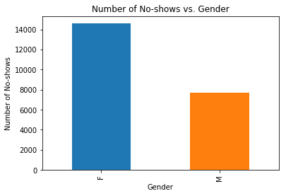

```python
#Plot the number of no-shows for each gender
#https://stackoverflow.com/questions/21487329/add-x-and-y-labels-to-a-pandas-plot
ax = df_appt.groupby(['Gender'])['numerical_noshow'].sum().plot(kind = 'bar', title = 'Number of No-shows vs. Gender');
ax.set(ylabel='Number of No-shows');
```

As we can see in the bar graph, there are nearly twice as many no-shows from female patients as there are from male patients.

However, this does not take into consideration the number of patients of each gender that are included in the data.

```python
#Find the number of male and female patients
df_appt['Gender'].value_counts()
```

```
F    71840
M    38687
Name: Gender, dtype: int64
```

Looking at the total number or patients of each gender, we see that there are nearly twice as many female patients as male patients. This difference can explain the large difference between males and females on the graph above. It also means that if we are interested in determining if there is a behavioral difference between the two genders, it would be more informative to look instead at the proportion of appointments that were no-shows for each gender.

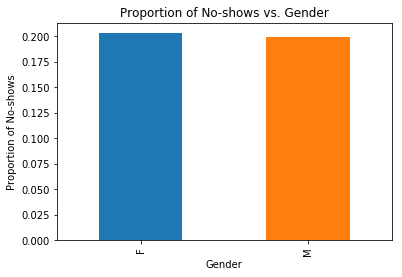

```python
#Plot the proportion of no-shows for each gender
ax = df_appt.groupby(['Gender'])['numerical_noshow'].mean().plot(kind = 'bar', title = 'Proportion of No-shows vs. Gender');
ax.set(ylabel='Proportion of No-shows');
```

Here, we utilized the numerical_noshow column, and take the mean value for each gender. As mentioned above, taking the mean of this column gives us the proportion of appointments that were no-shows.

After correcting for the fact that there are so many more female patients than male patients, there is still a small difference between the two, where female patients are slightly more likely to have a no-show. However, the difference is quite small, indicating that there is likely no relationship between gender and no-shows

### Research Question 2: What is the relationship between age and likelihood of a no-show?

To begin question 2, we want to look at what the different values of 'Age' are, to make sure they are all sensical.

```python
#Find an array of all of the unique age values, and sort it
ages = df_appt['Age'].unique()
np.sort(ages)
```

```
array([ -1,   0,   1,   2,   3,   4,   5,   6,   7,   8,   9,  10,  11,
        12,  13,  14,  15,  16,  17,  18,  19,  20,  21,  22,  23,  24,
        25,  26,  27,  28,  29,  30,  31,  32,  33,  34,  35,  36,  37,
        38,  39,  40,  41,  42,  43,  44,  45,  46,  47,  48,  49,  50,
        51,  52,  53,  54,  55,  56,  57,  58,  59,  60,  61,  62,  63,
        64,  65,  66,  67,  68,  69,  70,  71,  72,  73,  74,  75,  76,
        77,  78,  79,  80,  81,  82,  83,  84,  85,  86,  87,  88,  89,
        90,  91,  92,  93,  94,  95,  96,  97,  98,  99, 100, 102, 115],
      dtype=int64)
```

Since we saw earlier that there were only 104 unique values for age, printing out the unique values is not too untenable. Sorting allows us to look for numbers that don't make sense, which in the case of age would be negative, or too high. In this case, we see that an age of -1 was reported, so we want to ignore that, as it is not a sensical value for an age. An age of 115 seems potentially unlikely, but not impossible, so it will be left in.

```python
#Create a new dataframe with only ages above 0
df_age = df_appt.loc[df_appt['Age'] >= 0]
```

We can create a new dataframe to work with for this question, where we only are looking at ages greater than or equal to zero

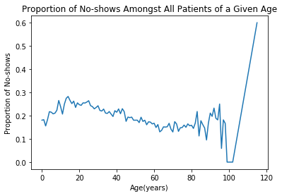

```python
#Plot the proportion of no-shows at each age value
ax = df_age.groupby('Age')['numerical_noshow'].mean().plot(title='Proportion of No-shows Amongst All Patients of a Given Age');
ax.set(xlabel="Age(years)", ylabel="Proportion of No-shows");
```

If we plot the proportion of no-shows for each age, we get the plot above. One thing we can see here is that there is quite a bit of noise in the data on the right side of the plot. To investigate why this may be, we can start by looking at how many times each age is represented in the dataframe.

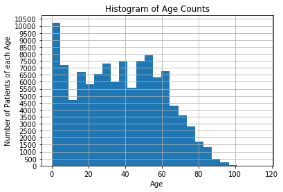

```python
#Create a histogram to show the distribution of ages
#https://matplotlib.org/api/_as_gen/matplotlib.pyplot.grid.html
#https://stackoverflow.com/questions/12608788/changing-the-tick-frequency-on-x-or-y-axis-in-matplotlib
ax = df_age['Age'].plot(kind='hist',bins=25,title='Histogram of Age Counts',grid=True, yticks=np.arange(0, 11000, 500));
ax.set(ylabel='Number of Patients of each Age', xlabel='Age');
```

```python
#Look at the data points for the final age in the list, which has the most outlying value
df_115 = df_age.loc[df_age['Age'] == 115]
df_115
```

|  | PatientId | Gender | ScheduledDay | AppointmentDay | Age | SMS_received | No_show | DateDifference | numerical_noshow |
| --- | --- | --- | --- | --- | --- | --- | --- | --- | --- |
| 63912 | 3.196321e+13 | F | 2016-05-16 | 2016-05-19 | 115 | 0 | Yes | 3 | 1 |
| 63915 | 3.196321e+13 | F | 2016-05-16 | 2016-05-19 | 115 | 0 | Yes | 3 | 1 |
| 68127 | 3.196321e+13 | F | 2016-04-08 | 2016-05-16 | 115 | 0 | Yes | 38 | 1 |
| 76284 | 3.196321e+13 | F | 2016-05-30 | 2016-05-30 | 115 | 0 | No | 0 | 0 |
| 97666 | 7.482346e+14 | F | 2016-05-19 | 2016-06-03 | 115 | 1 | No | 15 | 0 |

From this plot, we can see that there are far more data points at younger ages, beginning to taper off sharply around age 70. This is not surprising, as there simply are fewer elderly people in the population. However, this would explain the fact that the data is noisier for older ages; the sample size at those ages is smaller, and sometimes only one or two individuals.

Looking at the data points for an age of 115, for example, we can see that there are only two unique patient IDs, and that four of the five appointments and all three of the no-shows belong to one patient. Thus, this subset of data is more representative of a single individual than it is of all people of age 115.

To better visualize the data, it makes sense to remove the ages that do not have an appropriately large sample size. To do this, we will first use a function to add an additional column to the dataframe, which lists the number of occurrences of each age.

```python
#reate a function to add the value counts to the dataframe
#https://stackoverflow.com/questions/35809098/how-to-merge-pandas-value-counts-to-dataframe-or-use-it-to-subset-a-dataframe
def add_counts(df, column):
    """Counts the number of each unique value in a given column of a dataframe, and then appends the data to the dataframe
        as an additional column

        df -- dataframe input, to which the column of counted values will be added
        column -- the column in the input dataframe which will be counted
    """

    #Create a name for tne new column
    count_col = column.lower() + '_count'

    #Create a new dataframe containing the value counts, and name the columns
    df_count = pd.DataFrame(df[column].value_counts().reset_index())
    df_count.columns = [column, count_col]

    #Merge the new column with the input column
    return pd.merge(df, df_count, how='inner', on=column)
```

```python
#Check to see if the data is added correctly
df_age = add_counts(df_age, 'Age')
df_age.head()
```

|  | PatientId | Gender | ScheduledDay | AppointmentDay | Age | SMS_received | No_show | DateDifference | numerical_noshow | age_count |
| --- | --- | --- | --- | --- | --- | --- | --- | --- | --- | --- |
| 0 | 2.987250e+13 | F | 2016-04-29 | 2016-04-29 | 62 | 0 | No | 0 | 0 | 1312 |
| 1 | 4.262962e+12 | F | 2016-04-29 | 2016-04-29 | 62 | 0 | No | 0 | 0 | 1312 |
| 2 | 6.714489e+13 | M | 2016-04-06 | 2016-04-29 | 62 | 0 | No | 23 | 0 | 1312 |
| 3 | 5.637725e+14 | F | 2016-04-29 | 2016-04-29 | 62 | 0 | No | 0 | 0 | 1312 |
| 4 | 9.718557e+14 | F | 2016-04-28 | 2016-04-29 | 62 | 0 | No | 1 | 0 | 1312 |

Now that we have the age counts added, we can use this to pare down the dataframe to only include rows with a certain age count or higher.

```python
#Look at the statistics on the new column
df_age.describe()
```

|  | PatientId | Age | SMS_received | DateDifference | numerical_noshow | age_count |
| --- | --- | --- | --- | --- | --- | --- |
| count | 1.105260e+05 | 110526.000000 | 110526.000000 | 110526.000000 | 110526.000000 | 110526.000000 |
| mean | 1.474934e+14 | 37.089219 | 0.321029 | 10.183794 | 0.201934 | 1432.089716 |
| std | 2.560943e+14 | 23.110026 | 0.466874 | 15.255034 | 0.401445 | 505.564311 |
| min | 3.921784e+04 | 0.000000 | 0.000000 | -6.000000 | 0.000000 | 1.000000 |
| 25% | 4.172536e+12 | 18.000000 | 0.000000 | 0.000000 | 0.000000 | 1312.000000 |
| 50% | 3.173184e+13 | 37.000000 | 0.000000 | 4.000000 | 0.000000 | 1427.000000 |
| 75% | 9.438963e+13 | 55.000000 | 1.000000 | 15.000000 | 0.000000 | 1533.000000 |
| max | 9.999816e+14 | 115.000000 | 1.000000 | 179.000000 | 1.000000 | 3539.000000 |

Looking at the earlier histogram of ages, we see that we have a large peak at an age of 0, but that otherwise the counts are fairly consistent until about age 60, after which it drops off as there are fewer and fewer people at each age. In the statistical data, this is also seen by the fact that the 25th, 50th and 75th percentiles are all very similar.

Utilizing the histogram, we will choose the data where the age count is greater than 500. This encompasses all but the last few bars on the histogram, and therefore the vast majority of the data.

```python
#Create a new dataframe limited by age count
df_age_zoom = df_age.loc[df_age['age_count'] >= 500]
```

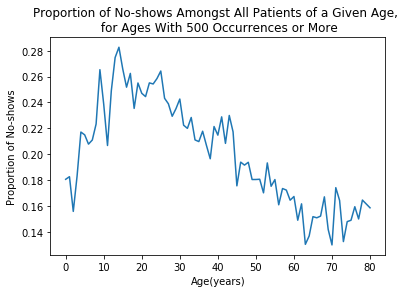

```python
#Plot the no-show data from the new, limited dataframe
ax = df_age_zoom.groupby('Age')['numerical_noshow'].mean().plot(title='Proportion of No-shows Amongst All Patients of a Given Age, \n for Ages With 500 Occurrences or More');
ax.set(xlabel="Age(years)", ylabel="Proportion of No-shows");
```

Upon plotting the adjusted data, we can now more clearly see how the data varies with age. We see a sharp uptick in no-shows as age progresses from 0 to ~20, followed by a continuous, gradual, roughly linear decrease that then flattens out around age 60.

### Research Question 3: How does the likelihood of a no-show vary with how far in advance an appointment is made? Is this affected by a patient receiving a text reminder?

We can begin question 3 in the same manner as question 2. Here we look at the different unique values for the number of days in advance that an appointment was made.

```python
dates = df_appt['DateDifference'].unique()
np.sort(dates)
```

```
array([ -6,  -1,   0,   1,   2,   3,   4,   5,   6,   7,   8,   9,  10,
        11,  12,  13,  14,  15,  16,  17,  18,  19,  20,  21,  22,  23,
        24,  25,  26,  27,  28,  29,  30,  31,  32,  33,  34,  35,  36,
        37,  38,  39,  40,  41,  42,  43,  44,  45,  46,  47,  48,  49,
        50,  51,  52,  53,  54,  55,  56,  57,  58,  59,  60,  61,  62,
        63,  64,  65,  66,  67,  68,  69,  70,  71,  72,  73,  74,  75,
        76,  77,  78,  79,  80,  81,  82,  83,  84,  85,  86,  87,  88,
        89,  90,  91,  92,  93,  94,  95,  96,  97,  98, 101, 102, 103,
       104, 105, 107, 108, 109, 110, 111, 112, 115, 117, 119, 122, 123,
       125, 126, 127, 132, 133, 139, 142, 146, 151, 155, 162, 169, 176,
       179], dtype=int64)
```

We can clearly eliminate the negative values, since this would indicate that the appointment was made after it had already passed, which is not sensical.

```python
df_appt = df_appt.sort_values(by=['DateDifference']).reset_index()
df_appt.head(10)
```

|  | index | PatientId | Gender | ScheduledDay | AppointmentDay | Age | SMS_received | No_show | DateDifference | numerical_noshow |
| --- | --- | --- | --- | --- | --- | --- | --- | --- | --- | --- |
| 0 | 71533 | 9.982316e+14 | F | 2016-05-11 | 2016-05-05 | 81 | 0 | Yes | -6 | 1 |
| 1 | 72362 | 3.787482e+12 | M | 2016-05-04 | 2016-05-03 | 7 | 0 | Yes | -1 | 1 |
| 2 | 64175 | 2.425226e+13 | F | 2016-05-05 | 2016-05-04 | 22 | 0 | Yes | -1 | 1 |
| 3 | 55226 | 7.896294e+12 | F | 2016-05-18 | 2016-05-17 | 19 | 0 | Yes | -1 | 1 |
| 4 | 27033 | 7.839273e+12 | M | 2016-05-10 | 2016-05-09 | 38 | 0 | Yes | -1 | 1 |
| 5 | 57785 | 6.357872e+13 | M | 2016-05-04 | 2016-05-04 | 46 | 0 | Yes | 0 | 1 |
| 6 | 57786 | 7.758559e+12 | F | 2016-05-18 | 2016-05-18 | 48 | 0 | No | 0 | 0 |
| 7 | 57787 | 8.867813e+12 | F | 2016-05-25 | 2016-05-25 | 58 | 0 | No | 0 | 0 |
| 8 | 57788 | 3.996494e+14 | M | 2016-05-18 | 2016-05-18 | 56 | 0 | No | 0 | 0 |
| 9 | 57789 | 1.637135e+13 | F | 2016-05-25 | 2016-05-25 | 47 | 0 | Yes | 0 | 1 |

```python
df_appt_trunc = df_appt.iloc[5:]
```

To plot the data we want, we can sort the data such that the negative values are at the top, and then create a new dataframe including all rows after that.

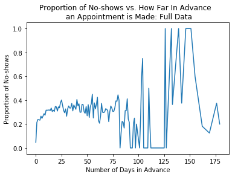

```python
#Plot the proportion of no-shows for each day count
ax = df_appt_trunc.groupby(['DateDifference'])['numerical_noshow'].mean().plot(title='Proportion of No-shows vs. How Far In Advance  \n an Appointment is Made: Full Data');
ax.set(xlabel="Number of Days in Advance", ylabel="Proportion of No-shows");
```

```python
df_151 = df_appt.loc[df_appt['DateDifference'] == 151]
df_151
```

|  | index | PatientId | Gender | ScheduledDay | AppointmentDay | Age | SMS_received | No_show | DateDifference | numerical_noshow |
| --- | --- | --- | --- | --- | --- | --- | --- | --- | --- | --- |
| 110471 | 46292 | 9.163747e+13 | M | 2015-12-03 | 2016-05-02 | 34 | 1 | Yes | 151 | 1 |

For example, the point with a date difference of 151 is only one single patient.

Next, we add the date difference counts to the dataframe, and plot the column in a histogram.

```python
#Add the date difference counts to the dataframe and check to see that it was properly added
df_appt = add_counts(df_appt, 'DateDifference')
df_appt.head()
```

|  | index | PatientId | Gender | ScheduledDay | AppointmentDay | Age | SMS_received | No_show | DateDifference | numerical_noshow | datedifference_count |
| --- | --- | --- | --- | --- | --- | --- | --- | --- | --- | --- | --- |
| 0 | 71533 | 9.982316e+14 | F | 2016-05-11 | 2016-05-05 | 81 | 0 | Yes | -6 | 1 | 1 |
| 1 | 72362 | 3.787482e+12 | M | 2016-05-04 | 2016-05-03 | 7 | 0 | Yes | -1 | 1 | 4 |
| 2 | 64175 | 2.425226e+13 | F | 2016-05-05 | 2016-05-04 | 22 | 0 | Yes | -1 | 1 | 4 |
| 3 | 55226 | 7.896294e+12 | F | 2016-05-18 | 2016-05-17 | 19 | 0 | Yes | -1 | 1 | 4 |
| 4 | 27033 | 7.839273e+12 | M | 2016-05-10 | 2016-05-09 | 38 | 0 | Yes | -1 | 1 | 4 |

```python
#Look at statistics for the new column
df_appt.describe()
```

|  | index | PatientId | Age | SMS_received | DateDifference | numerical_noshow | datedifference_count |
| --- | --- | --- | --- | --- | --- | --- | --- |
| count | 110527.000000 | 1.105270e+05 | 110527.000000 | 110527.000000 | 110527.000000 | 110527.000000 | 110527.000000 |
| mean | 55263.000000 | 1.474963e+14 | 37.088874 | 0.321026 | 10.183702 | 0.201933 | 15331.844952 |
| std | 31906.540939 | 2.560949e+14 | 23.110205 | 0.466873 | 15.254996 | 0.401444 | 17089.927217 |
| min | 0.000000 | 3.921784e+04 | -1.000000 | 0.000000 | -6.000000 | 0.000000 | 1.000000 |
| 25% | 27631.500000 | 4.172614e+12 | 18.000000 | 0.000000 | 0.000000 | 0.000000 | 1503.000000 |
| 50% | 55263.000000 | 3.173184e+13 | 37.000000 | 0.000000 | 4.000000 | 0.000000 | 5213.000000 |
| 75% | 82894.500000 | 9.439172e+13 | 55.000000 | 1.000000 | 15.000000 | 0.000000 | 38563.000000 |
| max | 110526.000000 | 9.999816e+14 | 115.000000 | 1.000000 | 179.000000 | 1.000000 | 38563.000000 |

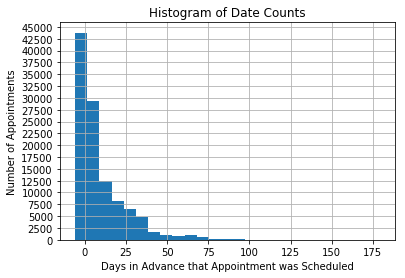

```python
#Plot a histogram of the date count data
ax = df_appt['DateDifference'].plot(kind='hist',bins=25,title='Histogram of Date Counts',grid=True, yticks=np.arange(0,45001,2500));
ax.set(ylabel='Number of Appointments', xlabel='Days in Advance that Appointment was Scheduled');
```

Looking at the histogram and the statistical data, the right skew to the data makes it difficult to pick where we would like the cutoff point to be, as far as limiting the data to the useful range.

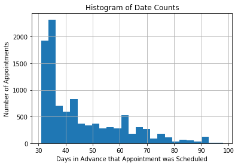

```python
#Plot just the tail of the histogram
ax = df_appt['DateDifference'].loc[(df_appt['DateDifference']>30) & (df_appt['DateDifference']<100)].plot(kind='hist',bins=25,title='Histogram of Date Counts',grid=True);
ax.set(ylabel='Number of Appointments', xlabel='Days in Advance that Appointment was Scheduled');
```

Using this zoomed in histogram, a y-value of about 200 would encompass a large portion of the tail of the graph, without including the points that would be too small a sample size to be useful.

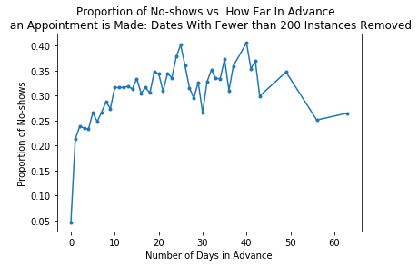

```python
#Plot the data with the adjusted dataframe
#https://stackoverflow.com/questions/43941245/line-plot-with-data-points-in-pandas
df_appt_adj = df_appt.loc[df_appt['datedifference_count'] >= 200]
ax = df_appt_adj.groupby(['DateDifference'])['numerical_noshow'].mean().plot(style='.-', title='Proportion of No-shows vs. How Far In Advance  \n an Appointment is Made: Dates With Fewer than 200 Instances Removed');
ax.set(xlabel="Number of Days in Advance", ylabel="Proportion of No-shows");
```

This adjusted plot gives us more information about the relationship between the no-shows and the days in advance that the appointment was booked. We see the sharp increase after zero days, then a gradual increase until about 40 days. After that, it becomes more difficult to see if it is dropping a bit, or remaining level.

We can also zoom in even more closely on the beginning of the graph, which shows a roughly linear increase after jumping up after 0:

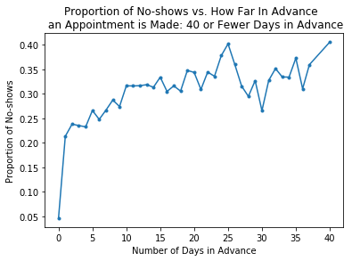

```python
df_appt_zoom = df_appt_adj.loc[df_appt['DateDifference'] <= 40]
ax = df_appt_zoom.groupby(['DateDifference'])['numerical_noshow'].mean().plot(style='.-',title='Proportion of No-shows vs. How Far In Advance  \n an Appointment is Made: 40 or Fewer Days in Advance');
ax.set(xlabel="Number of Days in Advance", ylabel="Proportion of No-shows");
```

From here, we can look at how our graph is affected by taking into account whether a person received a text message reminder or not.

[figure not shown]

```python
#Further limit the dataframe, such that we are looking at patients who received a text message
df_appt_sms = df_appt.loc[(df_appt['datedifference_count'] >= 200) & (df_appt['SMS_received'] == 1)]

#Plot the two data sets together
ax = df_appt_adj.groupby(['DateDifference'])['numerical_noshow'].mean().plot(style='.-', title='Proportion of No-shows vs. How Far In Advance  \n an Appointment is Made: Dates With Fewer than 200 Instances Removed');
ax.set(xlabel="Number of Days in Advance", ylabel="Proportion of No-shows");
ax = df_appt_sms.groupby(['DateDifference'])['numerical_noshow'].mean().plot(style='.-');
ax.legend(['No SMS','SMS']);
```

[figure not shown]

```python
#Close up comparison of with and without SMS
df_sms_zoom = df_appt_sms.loc[df_appt['DateDifference'] <= 40]
ax = df_appt_zoom.groupby(['DateDifference'])['numerical_noshow'].mean().plot(style='.-',title='Proportion of No-shows vs. How Far In Advance  \n an Appointment is Made: 40 or Fewer Days in Advance');
ax = df_sms_zoom.groupby(['DateDifference'])['numerical_noshow'].mean().plot(style='.-');
ax.set(xlabel="Number of Days in Advance", ylabel="Proportion of No-shows");
ax.legend(['No SMS','SMS']);
```

Looking at the full plot, as well as the truncated plot, it appears that the SMS reminder does decrease the likelihood of a no-show, as we see that the proportion of no-shows is lower amongst the subset of the population that received a text message

## Conclusions

*Question #1: What is the relationship between gender and likelihood of a no-show?*

Looking at the bar graph in part 1 of our analysis, which considers the proportion of patients of each gender who have a no-show appointment, we see that there is very little difference between male and female patients, with a slightly higher proportion of females having one. Based on this, it is most likely that there is not a relationship between the two; however, no tests have been done here to determine whether the difference between the two is statistically significant.

*Question #2: What is the relationship between age and likelihood of a no-show?*

Looking at the final plot in the question 2 analysis, we can see a few things. The likelihood of a no-show increases greatly from about age 0 to age 20; thus, it appears that throughout childhood, one is increasingly more likely to miss a scheduled appointment. Once we reach ~age 20, we see a gradual decrease in the proportion of patients who have had a no-show, leveling out as we approach age 60. So for adulthood, we see that as people get older, they are less likely to miss appointments.

This data though, is limited, and we cannot draw any definitive conclusions as to why we see the increase throughout childhood, followed by a decrease throughout adulthood. Further work would be to try to tie this data to other variables.

*Question #3: How does the likelihood of a no-show vary with how far in advance an appointment is made? Is this affected by a patient receiving a text reminder?*

The first thing that we see in this data makes perfect sense - a very low rate of no-shows when the appointment is scheduled within the current day. This is exactly what we would expect; because of the short time frame, the patients are less likely to forget or have circumstances come up which prevent them from attending their appointment.

*Overall Conclusions:* Overall, it can be concluded that age, text reminders, and how far in advance the appointment is made have an impact on the likelihood of a no show. Gender likely does not have a statistically significant impact.